# Représentation et inférence de réseaux avec R et Python

Saint-Clair Chabert-Liddell

August 26, 2020

## Utilisation de Python dans rmarkdown

Pour pouvoir utiliser `Python` dans `Rmarkdown` il faut utiliser le package `reticulate`. On peut lui préciser le chemin de la version que l’on veut utiliser une certaine version plutôt que celle par défaut. Si une version de `Python` est déjà chargée, il faut relancer la session `R` pour que la modification soit appliqué.

```r
library(reticulate)
use_python(python = "/usr/bin/python3.6", required = TRUE)
use_virtualenv("r-reticulate")
reticulate::py_config()
```

```
## python:         /usr/bin/python3.6
## libpython:      /usr/lib/python3.6/config-3.6m-x86_64-linux-gnu/libpython3.6.so
## pythonhome:     //usr://usr
## version:        3.6.9 (default, Jul 17 2020, 12:50:27)  [GCC 8.4.0]
## numpy:          /home/stc/.local/lib/python3.6/site-packages/numpy
## numpy_version:  1.17.4
##
## NOTE: Python version was forced by use_python function
```

Il suffit alors de créer un chunk avec `python` comme langage. Tous les objets `R` de l’environnement sont accessible via la commande `r.`.

```python
x = 2
print(x)
```

```
## 2
```

```python
r.x = x
```

Dans un chunk `R`, les objets `python` sont accessible avec la commande `py$`.

```r
x <- py$x
y <- x**2
print(y)
```

```
## [1] 4
```

```r
typeof(y)
```

```
## [1] "double"
```

Il faut faire attention à la transformation automatique des types de `R` vers `python`, ce dernier étant plus pointilleux que `R` la dessus.

```python
z = [i**2 for i in range(int(r.y))]

print(z)
```

```
## [0, 1, 4, 9]
```

## Utilisation de la librarie graph_tool

`graph_tool` est une librairie `python` pour analyser des réseaux développer par T. Peixoto. Elle permet entre autre de faire des visualisations interactive de graphes et est également très réputée pour ces implémentations du SBM et du degree corrected SBM.

```r
library(sbm)
library(igraph)
library(tidyverse)
```

```python
import graph_tool.all as gt
import matplotlib.pyplot as plt
import numpy as np
import math
import time
```

```python
g = gt.collection.data["football"]
print(g)
```

```
## <Graph object, undirected, with 115 vertices and 613 edges, 4 internal vertex properties, 2 internal graph properties, at 0x7efe7efad828>
```

```python
state = gt.minimize_blockmodel_dl(g)
m = state.get_matrix()
```

Les plots `matplotlib` sortent très bien dans le notebook, mais ce n’est pas le cas des plots interactifs. Ceux-ci ouvrent une fenêtre `python` interactive et bloquent la compilation du document.

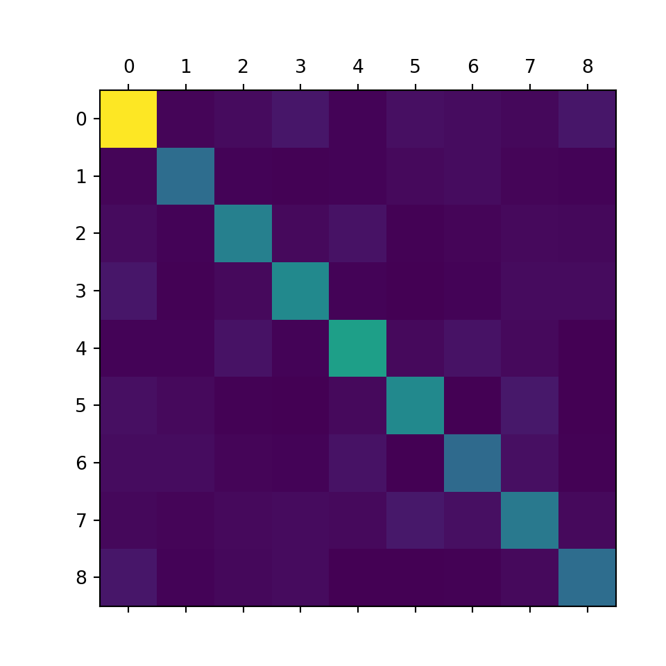

```python
plt.matshow(m.todense())
```

Si l’on décide de sortir un plot *inline*, la fenêtre virtuelle ne s’ouvre pas et l’on récupère juste l’adresse mémoire du graph stocker.

```python
pv = None
for i in range(1000):
     ret = state.mcmc_sweep(niter=10)
     pv = state.collect_vertex_marginals(pv)
gt.mf_entropy(g, pv)
```

```
## 2.830159554181248
```

```python
p = gt.graph_draw(g, pos=g.vp["pos"], vertex_shape="pie",
                  vertex_pie_fractions=pv, inline= True)
```

On obtient des représentations graphiques sur des graph assez gros (1500 noeuds) rapidement.

```python
g = gt.price_network(1500)
deg = g.degree_property_map("in")
deg.a = 4 * (np.sqrt(deg.a) * 0.5 + 0.4)
```

```python
ebet = gt.betweenness(g)[1]
ebet.a /= ebet.a.max() / 10.
eorder = ebet.copy()
eorder.a *= -1
pos = gt.sfdp_layout(g)
control = g.new_edge_property("vector<double>")
for e in g.edges():
    d = np.sqrt(sum((pos[e.source()].a - pos[e.target()].a) ** 2)) / 5
    control[e] = [0.3, d, 0.7, d]
gt.graph_draw(g, pos=pos, vertex_size=deg, vertex_fill_color=deg, vorder=deg,
              edge_color=ebet, eorder=eorder, edge_pen_width=ebet,
              edge_control_points=control) # some curvy edges
              #output="graph-draw.pdf")
```

```
## (<VertexPropertyMap object with value type 'vector<double>', for Graph 0x7efe30258ba8, at 0x7efe5181ddd8>, <VertexPropertyMap object with value type 'bool', for Graph 0x7efe30258ba8, at 0x7efe2bda8780>)
```

Et l’on peut également sortir des plots interactifs avec graphviz.

```python
g = gt.price_network(1500)
deg = g.degree_property_map("in")
deg.a = 2 * (np.sqrt(deg.a) * 0.5 + 0.4)
ebet = gt.betweenness(g)[1]
#gt.graphviz_draw(g, vcolor=deg, vorder=deg, elen=10,
#                 ecolor=ebet, eorder=ebet, )#, output="graphviz-draw.pdf")
```

```python
g = gt.price_network(3000)
pos = gt.sfdp_layout(g)
gt.graph_draw(g, pos=pos)#, output="graph-draw-sfdp.pdf")
```

```
## (<VertexPropertyMap object with value type 'vector<double>', for Graph 0x7efe2bda8cc0, at 0x7efe2bd9d630>, <VertexPropertyMap object with value type 'bool', for Graph 0x7efe2bda8cc0, at 0x7efe2bda8d68>)
```

```python
g = gt.collection.data["netscience"]
g = gt.GraphView(g, vfilt=gt.label_largest_component(g))
g.purge_vertices()
state = gt.minimize_nested_blockmodel_dl(g, deg_corr=True)
t = gt.get_hierarchy_tree(state)[0]
tpos = pos = gt.radial_tree_layout(t, t.vertex(t.num_vertices() - 1), weighted=True)
cts = gt.get_hierarchy_control_points(g, t, tpos)
pos = g.own_property(tpos)
b = state.levels[0].b
shape = b.copy()
shape.a %= 14
gt.graph_draw(g, pos=pos, vertex_fill_color=b, vertex_shape=shape,
              edge_control_points=cts,
              edge_color=[0, 0, 0, 0.3], vertex_anchor=0)#, output="netscience_nested_mdl.pdf")
```

```
## (<VertexPropertyMap object with value type 'vector<double>', for Graph 0x7efe2bd86208, at 0x7efe2bda8da0>, <VertexPropertyMap object with value type 'bool', for Graph 0x7efe2bd86208, at 0x7efe491fb240>)
```

Un essaie de plot hiérarchique:

```
## (<VertexPropertyMap object with value type 'vector<double>', for Graph 0x7efe3023ed68, at 0x7efe30258240>, <Graph object, directed, with 314 vertices and 313 edges, at 0x7efe3023e630>, <VertexPropertyMap object with value type 'vector<double>', for Graph 0x7efe3023e630, at 0x7efe491eacc0>)
```

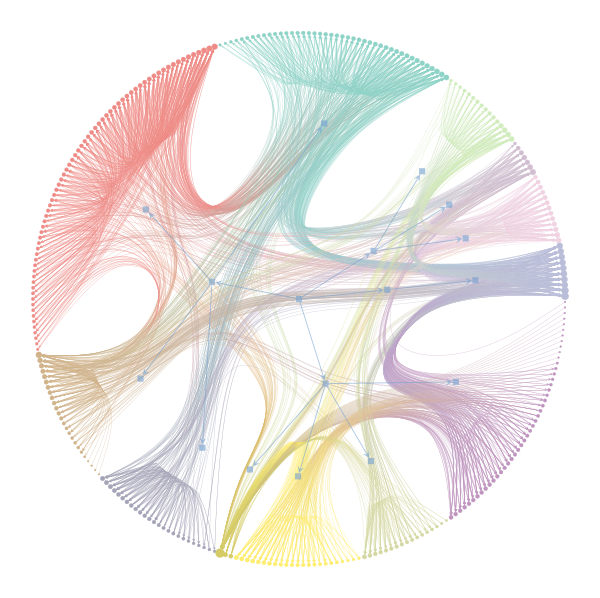

plot hierarchique

```python
g = gt.collection.data["celegansneural"]
state = gt.minimize_nested_blockmodel_dl(g, deg_corr=True)
gt.draw_hierarchy(state, output="./celegansneural_hier.png")
```

Si l’on fit un sbm sur un graph, l’autoplot sur l’état des blocks du graphe se fait automatiquement.

```python
t0 = time.time()
g = gt.collection.data["polbooks"]

state = gt.minimize_blockmodel_dl(g , deg_corr=False)
for i in range(10):
    s = gt.minimize_blockmodel_dl(g , deg_corr=False)
    if s.entropy() < state.entropy():
        state = s

t = t0 - time.time()
print(t)
```

```
## -3.0507216453552246
```

```python
state.entropy()
```

```
## 1323.2133521729672
```

```python
state.draw(pos=g.vp["pos"], vertex_shape=state.get_blocks())#,
```

```
## (<VertexPropertyMap object with value type 'vector<double>', for Graph 0x7efe2bda8668, at 0x7efe3023ea90>, <VertexPropertyMap object with value type 'bool', for Graph 0x7efe2bda8668, at 0x7efe302586d8>)
```

```
## <VertexPropertyMap object with value type 'vector<double>', for Graph 0x7efe2bda8668, at 0x7efe2bd9d358>
```

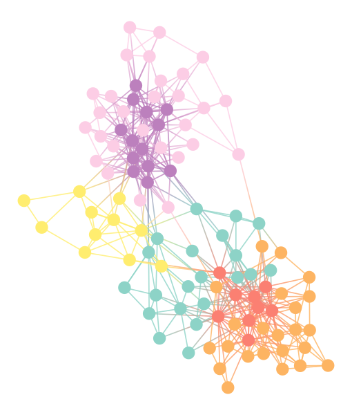

Image graph tools

```python
state.draw(output = "gt_plot.png" )
#...            output="polbooks_blocks_mdl.svg")
```

## Passe de `python` à `R`

On peut passer le réseau via la matrice d’adjacence de `python` à `R`, mais on aimerait mieux sortir un objet `graphml` qui est bien lu par `igraph`.

Malheureusement, cela ne fonctionne pas. Toutes les méthodes de `graph_tool` sur les noeuds et les arêtes renvoient des itérateurs. Il est nécessaire de les transformer en vecteur avec de les utiliser en `R`.

```python
blocks = [b for b in state.get_blocks()]
A = gt.adjacency(g)
g.save(file_name= "/home/stc/Documents/StateOfTheR/FinistR2020/graph_gt.graphml", fmt="graphml")
```

```r
#g <- igraph::read.graph("/home/stc/Documents/StateOfTheR/FinistR2020/graph_gt.graphml",                         format = "graphml")
```

```r
py$blocks + 1
```

```
##   [1] 1 1 1 2 1 1 1 1 2 2 2 2 2 2 1 3 3 3 1 3 1 3 1 3 1 1 1 3 4 1 5 5 3 3 3 3 3
##  [38] 3 3 3 2 3 3 3 3 1 3 2 1 1 1 6 6 1 3 3 3 1 6 4 4 4 4 4 6 6 5 6 6 6 4 5 5 5
##  [75] 5 5 5 4 4 4 4 4 4 4 5 6 5 4 4 4 4 4 4 4 4 4 4 4 4 5 5 4 4 6 6
```

```r
A <- as.matrix(py$A)
isSymmetric(A)
```

```
## [1] TRUE
```

```r
my_sbm <- blockmodels::BM_bernoulli("SBM_sym", A, verbosity = 0, plotting = "")
```

```r
t0 <- Sys.time()
my_sbm$estimate()
```

```r
t <- t0 - Sys.time()
t
```

```
## Time difference of -3.41299 secs
```

```r
aricode::ARI(c1 = py$blocks +1, c2 = my_sbm$memberships[[5]]$map()$C)
```

```
## [1] 0.7338193
```

```r
my_sbm$memberships[[5]]$map()$C
```

```
##   [1] 3 3 3 2 3 3 3 3 2 2 2 2 2 2 1 1 1 1 1 1 1 1 1 1 1 1 1 1 4 3 5 5 1 1 1 1 1
##  [38] 1 1 1 2 1 1 1 1 1 1 2 1 3 1 3 3 1 1 1 1 1 3 4 4 4 4 4 3 3 5 3 3 3 4 5 5 5
##  [75] 5 5 5 4 4 4 4 4 4 4 5 3 5 4 4 4 4 4 4 4 4 4 4 4 4 5 5 4 4 3 3
```

```r
py$blocks +1
```

```
##   [1] 1 1 1 2 1 1 1 1 2 2 2 2 2 2 1 3 3 3 1 3 1 3 1 3 1 1 1 3 4 1 5 5 3 3 3 3 3
##  [38] 3 3 3 2 3 3 3 3 1 3 2 1 1 1 6 6 1 3 3 3 1 6 4 4 4 4 4 6 6 5 6 6 6 4 5 5 5
##  [75] 5 5 5 4 4 4 4 4 4 4 5 6 5 4 4 4 4 4 4 4 4 4 4 4 4 5 5 4 4 6 6
```

Les clustering obtenus par `graph-tool` et sbm (`blockmodels`) sont très proche pour le sbm simple.

```r
igraph::graph_from_adjacency_matrix(
  A, mode = "directed") %>% igraph::write_graph(file = "graph_test.graphml", format = "graphml")
```

```python
gr = gt.load_graph(file_name="~/Documents/StateOfTheR/FinistR2020/graph_test.graphml", fmt="graphml")
```

```python
gr.set_directed = False
gt.minimize_blockmodel_dl(gr, deg_corr=False)
```

```
## <BlockState object with 9 blocks (9 nonempty), for graph <Graph object, directed, with 105 vertices and 882 edges, 1 internal vertex property, 1 internal edge property, at 0x7efe2bda8908>, at 0x7efe45fb8668>
```

## Reste à faire

- Trouver une meilleur méthode pour passer un objet de type graph de `python` vers `R`. Une solution serait peut-être d’utiliser le module `igraph` de `python`.
- Est-il possible de capturer une fenêtre interactive `python` pour la mettre dans la sortie html du `rmarkdown` ?